# Week 8 Lecture - Bivariate Correlation

Undergraduate Research Methods in Psychology

Quinton Quagliano, M.S., C.S.P

Department of Psychology

# 1 Chapter Overview

## 1.1 Learning Objectives

- Explain that measured variables - not any particular statistic - make a study correlational.
- Interrogate the construct validity and statistical validity (and, of lower priority, external validity) of an association claim.
- Explain why a correlational study can support an association claim, but not a causal claim.
- Be able to understand the defining characteristics of a correlational, bivariate research design
- Be able to use appropriate vocabulary and logic used in describing and assessing bivariate designs

## 1.2 Chapter Overview

- Moving forward, much of the content will be about applying chapters 1 - 7 to different research designs. Make sure you review vocab from the first half of class, as it will often come back in these upcoming lectures.
- “Bivariate” $\rightarrow$ means two variables
- Two, **measured** variables $\rightarrow$ likely an association claim being made
- *Review:* Remember the vocabulary we should expect with associative claims between
  - Example: linked, “associated with”, “correlated with”, etc.
- **Discuss: Any other examples of vocab normally used with associative claims?**

# 2 Bivariate Correlation

## 2.1 Overview

- *Review:* Recall that there are three possible association /relationship descriptions between two variables:
  - Positive
  - Negative
  - Zero/no relationship
- Also recall that these are descriptors for linear or straight-line relationships - we’ll discuss how curvilinear relationships are a bit more complicated later today

## 2.2 Association Between Two Continuous Variables

- Example:
  - Two self-report measurements continuous outcome are strongly, positively correlated with one another
  - *Review:* what type of validity is this possibly associated with?
- **Discuss: What statistic do we use for association between two continuous variables, and what value would indicate a strong, positive relationship?**
- *Review:* When using correlation between two continuous variables, scatterplots are the most appropriate graphing method

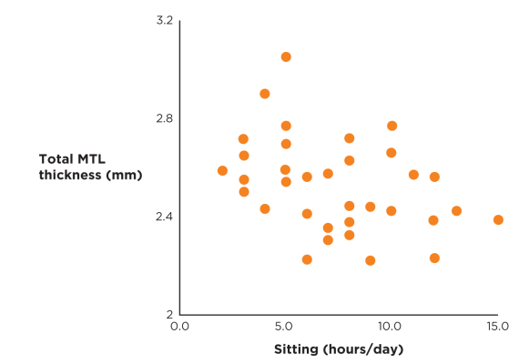

## 2.3 Association Between Categorical and Continuous Variables

- The prior example shows how to work with continuous variables, what about when we have one categorical/discrete and one continuous variable?
- One option: A sort of split scatterplot by the categorical variable

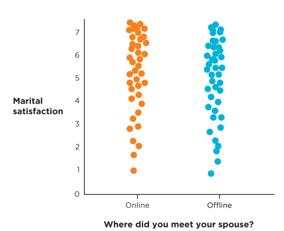

- **Discuss: What do you think is the direction and strength of relationship here?**
- In most cases, we will probably prefer other methods to graphical display information when we have categorical and continuous variables, as the split scatterplot can be somewhat confusing or difficult to interpret.
- Another option: A bar graph

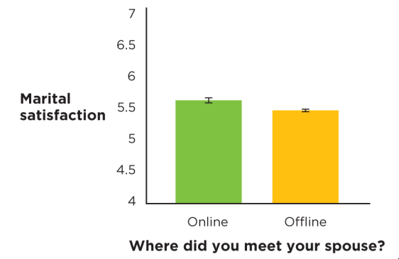

- **Discuss: What do you all think those small, black bars mean? What sorts of helpful information could they tell us about differences between the groups?**

## 2.4 Fully Correlation Design

- A correlational design is one that results from all relevant variables being measured, *not* based on what scale of measurement was used, statistic, or graph.
- The designs that we discuss are largely defined by whether variables are measured or manipulated *and* the relationship we hypothesize between the variables (i.e., what claim we are attempting to make)

# 3 Critical Association Claims

## 3.1 Construct Validity

- *Review:* construct validity is all about the measurement reliability and validity of the tools we use to measure a phenomenon.
  - 3 reliabilities: test-retest, interrater, and internal
  - 5 validities: face, content, criterion, convergent, divergent/discriminant
- Use the terms and suggestions from chapters 5 and 6 to assess this!
- Example: One of the items on one of my measures may not be measuring the same constructs as the others due to questionable use of the word “not” in the item.
- **Discuss: How would we identify an item not well correlated with other items of the same construct (hint: what statistics and what measurement validity type)? What vocabulary do we use to describe this problem presented by 'not' in the question?**

## 3.2 Statistical Validity

- Statistical validity has multiple components to be looking for:

### Effect Size

- Effect size is all about the *magnitude* of the results we found, it is not the same as significance.
- Assessing $r$ correlation coefficient effect
  - General guideline for behavioral sciences: 0.10 (weak), 0.20 (moderate), 0.30 (powerful), >0.40 (very powerful)
- We may also use r-squared
  - This refers to the amount of variance that one variable accounts for in another
- Low effect size $\rightarrow$ possible negligible or non-meaningful effect
- High effect size $\rightarrow$ possible meaningful/impactful effect
- Example: My continuous variables x and y have an r = 0.50 and $r^2$ = 0.25
  - This would be considered a very strong or powerful effect

### Precision

- *Review from stats class:* What do we call the intervals in which 95% of estimates will fall? confidence intervals
- Common notation: CI 95%:[Low-end Estimate, High-end Estimate]
- Larger sample size $\rightarrow$ usually smaller confidence intervals
- More precision = “better”, more accurate estimate
- Example: For an r statistic of 0.30, I have CI 95%:[0.28, 0.32], this shows a precise estimate with narrow confidence intervals

### Replication

- A question we should ask: has this association been shown before in the literature?
- We may replicate the study and measurements again on a new group and see if we get a similar value
- *Review:* This is a good use case for literature review and meta-analysis articles, as they can compile different studies investigating the same association. Remember, we are looking for the weight of evidence in favor of a claim.
- **Discuss: What have you all heard about replication in science in your other classes?**

### Outliers

- **Discuss: Based on what you all know from previous classes, what is the definition of an outlier?**
- An outlier, especially one extreme on both variables, can greatly sway the relationship of two variables.
- However, we should not simply throw out outliers because they are inconvenient findings.
  - Instead, we may consider **robust/non-parametric** statistics that can work around them as is
- Depending on who you ask, any value 3 or 4 standard deviations away from the mean would be considered an outlier.

### Restriction of Range

- This is when we do not have points across the full number of possible levels on one or both of our variables

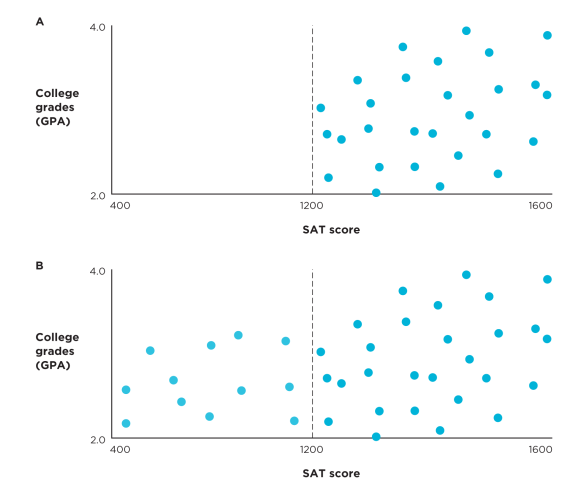

- Example: the possible scores on the test are 0 - 100, but all students only got between 70 and 85 $\rightarrow$ this is restriction of range problem.

### Curvilinear Relationships

- $r$ assumes a linear relationship between the two variables, but this is not true of all relationships in reality

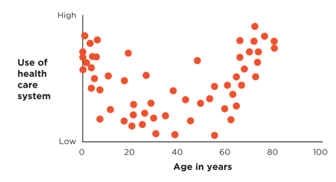

## 3.3 Internal Validity

- For association claims, we do not need to be concerned with meeting standards of internal validity, because a correlative design cannot explorecausal relationships.
- **Discuss: What research design can investigate a causal relationship**
- *Review:* What is the common phrase we use to describe the relationship between correlation and causation?
  - Correlation does not equal causation
  - Put simply, association alone does not tell us one “caused” the other!
- *Review:* What were the 3 causation criteria to establish a causal claim?
  - Covariance
  - Temporal Precedence - **directionality problem**
  - Internal validity - **third-variable problem**

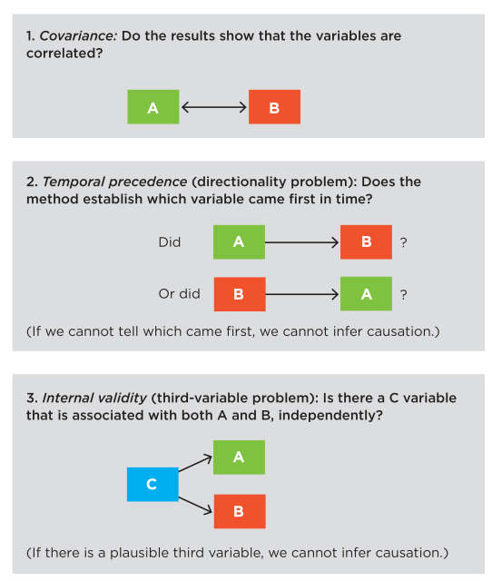

- Example: I am measuring the relationship between exercise and feeling of self-worth, both measured as continuous
  - High, positive correlation between the two - can I say exercise causes higher self-worth? No!
  - Say energy level is correlated with both exercise and feeling of self-worth, then what really is the cause?
  - What is the so-called *third-variable* here? Energy level

## 3.4 External Validity

- **Discuss: What matters more for 'good', representative sampling: size of sample or methodology?**
- Bad external validity does not necessarily invalidate a claim, but just limits its generalizability
- Example: I use quota sampling to gather my participants, and find an r = 0.60 relationship between the variables
  - What direction and strength of relationship is this? positive and strong.
  - Is this a biased or unbiased sample? biased! As it is non-probabilistic
- Moderators are some third variable that plays a partial role in the relationship between two variable
  - These may result in a broader, more complicated theory around certain constructs
  - But most psychological constructs are complex!

# 4 Key Points

## 4.1 Key Points

- Bivariate, correlational designs are those that focus on the relationship between two measured variables, i.e., investigating an association claim
- Assessing a study using this design is a function of (mostly) external, statistical, and construct validity. Internal validity doesn’t really apply, as we are missing the critical criteria necessary for a causal claim.
- We have several ways to graphically and statistically represent the relationship between two variables, but we also have several considerations such as effect size and precision of our estimate.
- We began to discuss some of the nuance in assessing internal validity, we’ll return to this as we creep closer to experiments!

[figure not shown]

Week 8 Lecture - Bivariate Correlation || Undergraduate Research Methods in Psychology